# Tutorial-Main_AMiGA_Functions_and_Classes

The **objective** of this tutorial is to showcase for advanced users how to adopt AMiGA code into their own scripts instead of relying on the command-line interface (CLI). Here, I will introdue functions and classes that can be used in a standalone manner for importing data and meta-data, processing growth curves, and fitting growth curves using Gaussian Process (which is implemented using the GPy package).

Import Packages  
Impot AMiGA functions  
Read example data  
GrowthPlate object  
GrowthPlate methods  
GrowthModel object  
Curve object  
Pooling example  
Estimating confidence intervals for OD  
Estimating confidence intervals for parameters

## Import packages

```python
import sys
import numpy as np
import pandas as pd
import matplotlib.pyplot as plt

plt.rcParams['font.family'] = 'Arial'
plt.rcParams['font.size'] = '20'
```

## Import AMiGA functions

WARNING: You will have to replace the the path to match amiga's location on your local machine.

```python
amiga = '/Users/firasmidani/rab_fm/git/amiga'
sys.path.append(amiga)

from amiga.libs.detail import assembleMappings
from amiga.libs.read import readPlateReaderFolder
from amiga.libs.trim import trimInput, annotateMappings,trimMergeMapping,trimMergeData
from amiga.libs.plot import largeTickLabels

from amiga.libs.growth import GrowthPlate
from amiga.libs.model import GrowthModel
from amiga.libs.curve import GrowthCurve

from amiga.libs.utils import subsetDf
```

## Read "death" example data

We will use the "death" example data set included in the Github repository for this tutorial.

```python
# define paths to data and ampping folders
path_data = '{}/examples/manuscript/death/data'.format(amiga)
path_mapping = '{}/examples/manuscript/death/mapping'.format(amiga)
```

Define plate reader interval (time interval between subsequent measurements) of optical density. You can pass a single default value or file-specific values.

```python
# single default value (units in seconds)
interval = 600

# dictionary that maps each data file name to its time interval value (units in seconds)
interval = {'2020-06-22-R1':600,'2020-06-22-R2':600,'2020-06-22-R3':600}
```

**`readPlateReaderFolder()`** can be used to parse a single file or multiple files at once. It returns a dictionary with file names as keys and formatted and tabulated data as values.

```python
# read data files
data = readPlateReaderFolder(directory=path_data,interval=interval)
```

```python
data['2020-06-22-R1']
```

|  | Time | A1 | A2 | A3 | A4 | A5 | A6 | A7 | A8 | A9 | ... | H3 | H4 | H5 | H6 | H7 | H8 | H9 | H10 | H11 | H12 |
| --- | --- | --- | --- | --- | --- | --- | --- | --- | --- | --- | --- | --- | --- | --- | --- | --- | --- | --- | --- | --- | --- |
| 0 | 0.0 | 0.105 | 0.099 | 0.096 | 0.100 | 0.099 | 0.094 | 0.094 | 0.080 | 0.082 | ... | 0.070 | 0.071 | 0.073 | 0.069 | 0.065 | 0.070 | 0.069 | 0.069 | 0.071 | 0.073 |
| 1 | 600.0 | 0.103 | 0.097 | 0.095 | 0.098 | 0.098 | 0.093 | 0.093 | 0.080 | 0.081 | ... | 0.069 | 0.071 | 0.073 | 0.069 | 0.065 | 0.069 | 0.068 | 0.069 | 0.071 | 0.073 |
| 2 | 1200.0 | 0.102 | 0.097 | 0.095 | 0.098 | 0.098 | 0.093 | 0.092 | 0.080 | 0.080 | ... | 0.069 | 0.071 | 0.073 | 0.068 | 0.065 | 0.070 | 0.069 | 0.069 | 0.071 | 0.073 |
| 3 | 1800.0 | 0.101 | 0.097 | 0.096 | 0.098 | 0.098 | 0.092 | 0.092 | 0.080 | 0.080 | ... | 0.069 | 0.071 | 0.073 | 0.069 | 0.065 | 0.069 | 0.068 | 0.069 | 0.071 | 0.073 |
| 4 | 2400.0 | 0.101 | 0.098 | 0.097 | 0.098 | 0.098 | 0.093 | 0.092 | 0.079 | 0.080 | ... | 0.069 | 0.071 | 0.073 | 0.069 | 0.065 | 0.070 | 0.069 | 0.069 | 0.071 | 0.073 |
| ... | ... | ... | ... | ... | ... | ... | ... | ... | ... | ... | ... | ... | ... | ... | ... | ... | ... | ... | ... | ... | ... |
| 140 | 84000.0 | 0.342 | 0.210 | 0.149 | 0.381 | 0.390 | 0.494 | 0.497 | 0.373 | 0.385 | ... | 0.074 | 0.071 | 0.073 | 0.070 | 0.066 | 0.069 | 0.068 | 0.069 | 0.071 | 0.073 |
| 141 | 84600.0 | 0.334 | 0.204 | 0.148 | 0.359 | 0.388 | 0.491 | 0.497 | 0.368 | 0.382 | ... | 0.074 | 0.071 | 0.073 | 0.070 | 0.066 | 0.069 | 0.068 | 0.069 | 0.071 | 0.073 |
| 142 | 85200.0 | 0.323 | 0.198 | 0.147 | 0.337 | 0.386 | 0.487 | 0.493 | 0.362 | 0.379 | ... | 0.074 | 0.071 | 0.073 | 0.070 | 0.066 | 0.069 | 0.068 | 0.069 | 0.071 | 0.073 |
| 143 | 85800.0 | 0.313 | 0.194 | 0.147 | 0.317 | 0.385 | 0.481 | 0.491 | 0.356 | 0.376 | ... | 0.074 | 0.071 | 0.073 | 0.070 | 0.066 | 0.069 | 0.068 | 0.068 | 0.071 | 0.073 |
| 144 | 86400.0 | 0.300 | 0.187 | 0.145 | 0.297 | 0.381 | 0.477 | 0.486 | 0.348 | 0.372 | ... | 0.074 | 0.071 | 0.073 | 0.070 | 0.066 | 0.069 | 0.068 | 0.069 | 0.071 | 0.073 |

145 rows × 97 columns

**`assembleMappings()`** can be used to parse meta-data.

```python
# read mapping files
mappings = assembleMappings(data,path_mapping)
```

```python
mappings['2020-06-22-R1']
```

| Well | Plate_ID | Substrate | Concentration | Isolate | Ribotype | Group | Control | Flag | Subset |
| --- | --- | --- | --- | --- | --- | --- | --- | --- | --- |
| A1 | 2020-06-22-R1 | Glucose | Low | CD1007 | RT053 | 1 | 0 | 0 | 1 |
| B1 | 2020-06-22-R1 | Glucose | High | CD1007 | RT053 | 1 | 0 | 0 | 1 |
| C1 | 2020-06-22-R1 | Fructose | Low | CD1007 | RT053 | 1 | 0 | 0 | 1 |
| D1 | 2020-06-22-R1 | Fructose | High | CD1007 | RT053 | 1 | 0 | 0 | 1 |
| E1 | 2020-06-22-R1 | Trehalose | Low | CD1007 | RT053 | 1 | 0 | 0 | 1 |
| ... | ... | ... | ... | ... | ... | ... | ... | ... | ... |
| D12 | 2020-06-22-R1 | Fructose | High | M120 | RT078 | 12 | 0 | 0 | 1 |
| E12 | 2020-06-22-R1 | Trehalose | Low | M120 | RT078 | 12 | 0 | 0 | 1 |
| F12 | 2020-06-22-R1 | Trehalose | High | M120 | RT078 | 12 | 0 | 0 | 1 |
| G12 | 2020-06-22-R1 | Water | None | M120 | RT078 | 12 | 1 | 0 | 1 |
| H12 | 2020-06-22-R1 | NaN | NaN | NaN | NaN | 0 | 0 | 0 | 1 |

96 rows × 9 columns

**`trimInput()`** allows you to merge the data and mapping and also trim or subset the data based on user-defined parameters. The `subset` entry of the dictionary indicates which conditions I need to keep. The keys (i.e. `Substrate`, `Concentration`, and `Isolate`) must already be included in the meta-data files as column headers. The values must be actual values in these respective columns.

```python
# trim samples based on meta-data
params = {
          'subset' : {'Substrate':['Water','Fructose'],
                      'Concentration':['None','High'],
                      'Isolate':['CD1007']},
          'flag' : {},
          'hypothesis' : {},
          'interval' : {}
         }

sub_data,sub_mappings = trimInput(data,mappings,params)

nsamples = sub_mappings.shape[0]
ntimepoints = sub_data.shape[0]

assert nsamples == (sub_data.shape[1] - 1)

print('Shape of Data: {} time points and {} samples'.format(ntimepoints,nsamples))
print('Shape of Mappings: {} samples by {} variables'.format(*sub_mappings.shape))
```

```
Shape of Data: 145 time points and 6 samples
Shape of Mappings: 6 samples by 10 variables
```

```python
mappings['2020-06-22-R1']
```

| Well | Plate_ID | Substrate | Concentration | Isolate | Ribotype | Group | Control | Flag | Subset |
| --- | --- | --- | --- | --- | --- | --- | --- | --- | --- |
| A1 | 2020-06-22-R1 | Glucose | Low | CD1007 | RT053 | 1 | 0 | 0 | 1 |
| B1 | 2020-06-22-R1 | Glucose | High | CD1007 | RT053 | 1 | 0 | 0 | 1 |
| C1 | 2020-06-22-R1 | Fructose | Low | CD1007 | RT053 | 1 | 0 | 0 | 1 |
| D1 | 2020-06-22-R1 | Fructose | High | CD1007 | RT053 | 1 | 0 | 0 | 1 |
| E1 | 2020-06-22-R1 | Trehalose | Low | CD1007 | RT053 | 1 | 0 | 0 | 1 |
| ... | ... | ... | ... | ... | ... | ... | ... | ... | ... |
| D12 | 2020-06-22-R1 | Fructose | High | M120 | RT078 | 12 | 0 | 0 | 1 |
| E12 | 2020-06-22-R1 | Trehalose | Low | M120 | RT078 | 12 | 0 | 0 | 1 |
| F12 | 2020-06-22-R1 | Trehalose | High | M120 | RT078 | 12 | 0 | 0 | 1 |
| G12 | 2020-06-22-R1 | Water | None | M120 | RT078 | 12 | 1 | 0 | 1 |
| H12 | 2020-06-22-R1 | NaN | NaN | NaN | NaN | 0 | 0 | 0 | 1 |

96 rows × 9 columns

```python
full_data,full_mappings = trimInput(data,mappings)

nsamples = full_mappings.shape[0]
ntimepoints = full_data.shape[0]

assert nsamples == (full_data.shape[1] - 1)

print('Shape of Data: {} time points and {} samples'.format(ntimepoints,nsamples))
print('Shape of Mappings: {} samples by {} variables'.format(*full_mappings.shape))
```

```
Shape of Data: 145 time points and 288 samples
Shape of Mappings: 288 samples by 10 variables
```

**AMiGA formats data file as follows:**

```python
sub_data
```

| Sample_ID | Time | 0 | 1 | 2 | 3 | 4 | 5 |
| --- | --- | --- | --- | --- | --- | --- | --- |
| 0 | 0.0 | 0.101 | 0.096 | 0.088 | 0.090 | 0.101 | 0.091 |
| 1 | 600.0 | 0.099 | 0.095 | 0.087 | 0.089 | 0.098 | 0.089 |
| 2 | 1200.0 | 0.097 | 0.094 | 0.087 | 0.088 | 0.099 | 0.089 |
| 3 | 1800.0 | 0.097 | 0.094 | 0.087 | 0.088 | 0.096 | 0.088 |
| 4 | 2400.0 | 0.098 | 0.094 | 0.087 | 0.088 | 0.098 | 0.088 |
| ... | ... | ... | ... | ... | ... | ... | ... |
| 140 | 84000.0 | 0.494 | 0.226 | 0.438 | 0.158 | 0.450 | 0.207 |
| 141 | 84600.0 | 0.497 | 0.227 | 0.437 | 0.157 | 0.450 | 0.208 |
| 142 | 85200.0 | 0.488 | 0.229 | 0.435 | 0.157 | 0.454 | 0.208 |
| 143 | 85800.0 | 0.498 | 0.227 | 0.435 | 0.157 | 0.451 | 0.207 |
| 144 | 86400.0 | 0.494 | 0.231 | 0.433 | 0.156 | 0.447 | 0.208 |

145 rows × 7 columns

**AMiGA formats mapping file as follows:**

```python
sub_mappings
```

| Sample_ID | Well | Plate_ID | Substrate | Concentration | Isolate | Ribotype | Group | Control | Flag | Subset |
| --- | --- | --- | --- | --- | --- | --- | --- | --- | --- | --- |
| 0 | D1 | 2020-06-22-R1 | Fructose | High | CD1007 | RT053 | 1 | 0 | 0 | 1 |
| 1 | G1 | 2020-06-22-R1 | Water | None | CD1007 | RT053 | 1 | 1 | 0 | 1 |
| 2 | D1 | 2020-06-22-R2 | Fructose | High | CD1007 | RT053 | 1 | 0 | 0 | 1 |
| 3 | G1 | 2020-06-22-R2 | Water | None | CD1007 | RT053 | 1 | 1 | 0 | 1 |
| 4 | D1 | 2020-06-22-R3 | Fructose | High | CD1007 | RT053 | 1 | 0 | 0 | 1 |
| 5 | G1 | 2020-06-22-R3 | Water | None | CD1007 | RT053 | 1 | 1 | 0 | 1 |

**You can easily plot the raw data**

The three curves with low OD correspond to growth on minimal media only while the three curves with high OD correspond to growth on minimal media supplemented with fructose.

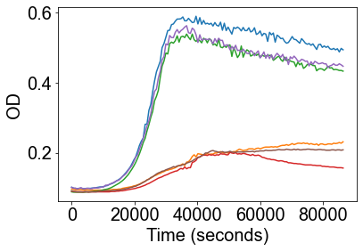

```python
fig,ax = plt.subplots(figsize=[6,4])

# the first column of sub_data is time, and remaining columns are sample-specific
ax.plot(sub_data.Time,sub_data.iloc[:,1:]);
ax.set(**{'xlabel':'Time (seconds)','ylabel':'OD'});
```

## GrowthPlate object

`GrowthPlate` is a class that allows you to save data in a standard format amenable to several tansformations.

The main attributes of `GrowthPlate` are `time`, `data`, and `key`.

See `?GrowthPlate` for more info.

```python
plate = GrowthPlate(data=sub_data,key=sub_mappings)
plate
```

```
<libs.growth.GrowthPlate at 0x7fd7fdefcf10>
```

```python
plate.time
```

|  | Time |
| --- | --- |
| 0 | 0.0 |
| 1 | 600.0 |
| 2 | 1200.0 |
| 3 | 1800.0 |
| 4 | 2400.0 |
| ... | ... |
| 140 | 84000.0 |
| 141 | 84600.0 |
| 142 | 85200.0 |
| 143 | 85800.0 |
| 144 | 86400.0 |

145 rows × 1 columns

```python
plate.data
```

| Sample_ID | 0 | 1 | 2 | 3 | 4 | 5 |
| --- | --- | --- | --- | --- | --- | --- |
| 0 | 0.101 | 0.096 | 0.088 | 0.090 | 0.101 | 0.091 |
| 1 | 0.099 | 0.095 | 0.087 | 0.089 | 0.098 | 0.089 |
| 2 | 0.097 | 0.094 | 0.087 | 0.088 | 0.099 | 0.089 |
| 3 | 0.097 | 0.094 | 0.087 | 0.088 | 0.096 | 0.088 |
| 4 | 0.098 | 0.094 | 0.087 | 0.088 | 0.098 | 0.088 |
| ... | ... | ... | ... | ... | ... | ... |
| 140 | 0.494 | 0.226 | 0.438 | 0.158 | 0.450 | 0.207 |
| 141 | 0.497 | 0.227 | 0.437 | 0.157 | 0.450 | 0.208 |
| 142 | 0.488 | 0.229 | 0.435 | 0.157 | 0.454 | 0.208 |
| 143 | 0.498 | 0.227 | 0.435 | 0.157 | 0.451 | 0.207 |
| 144 | 0.494 | 0.231 | 0.433 | 0.156 | 0.447 | 0.208 |

145 rows × 6 columns

```python
plate.key
```

| Sample_ID | Well | Plate_ID | Substrate | Concentration | Isolate | Ribotype | Group | Control | Flag | Subset |
| --- | --- | --- | --- | --- | --- | --- | --- | --- | --- | --- |
| 0 | D1 | 2020-06-22-R1 | Fructose | High | CD1007 | RT053 | 1 | 0 | 0 | 1 |
| 1 | G1 | 2020-06-22-R1 | Water | None | CD1007 | RT053 | 1 | 1 | 0 | 1 |
| 2 | D1 | 2020-06-22-R2 | Fructose | High | CD1007 | RT053 | 1 | 0 | 0 | 1 |
| 3 | G1 | 2020-06-22-R2 | Water | None | CD1007 | RT053 | 1 | 1 | 0 | 1 |
| 4 | D1 | 2020-06-22-R3 | Fructose | High | CD1007 | RT053 | 1 | 0 | 0 | 1 |
| 5 | G1 | 2020-06-22-R3 | Water | None | CD1007 | RT053 | 1 | 1 | 0 | 1 |

## GrowthPlate methods

**You can compute Min OD, Max OD, and Initial OD**

```python
# compute min od, max od
plate.computeBasicSummary()
plate.key
```

| Sample_ID | Well | Plate_ID | Substrate | Concentration | Isolate | Ribotype | Group | Control | Flag | Subset | OD_Baseline | OD_Min | OD_Max |
| --- | --- | --- | --- | --- | --- | --- | --- | --- | --- | --- | --- | --- | --- |
| 0 | D1 | 2020-06-22-R1 | Fructose | High | CD1007 | RT053 | 1 | 0 | 0 | 1 | 0.101 | 0.097 | 0.590 |
| 1 | G1 | 2020-06-22-R1 | Water | None | CD1007 | RT053 | 1 | 1 | 0 | 1 | 0.096 | 0.093 | 0.231 |
| 2 | D1 | 2020-06-22-R2 | Fructose | High | CD1007 | RT053 | 1 | 0 | 0 | 1 | 0.088 | 0.087 | 0.539 |
| 3 | G1 | 2020-06-22-R2 | Water | None | CD1007 | RT053 | 1 | 1 | 0 | 1 | 0.090 | 0.088 | 0.201 |
| 4 | D1 | 2020-06-22-R3 | Fructose | High | CD1007 | RT053 | 1 | 0 | 0 | 1 | 0.101 | 0.096 | 0.563 |
| 5 | G1 | 2020-06-22-R3 | Water | None | CD1007 | RT053 | 1 | 1 | 0 | 1 | 0.091 | 0.087 | 0.210 |

**You can comptue Fold Change relative to control wells**

In the meta-data files, I manually added `Group` and `Control` columns to indicate how fold-changes should be calculated. For each unique Group, there must be at least one Control sample.

```python
plate.computeFoldChange(subtract_baseline=True)
plate.key
```

| Sample_ID | Well | Plate_ID | Substrate | Concentration | Isolate | Ribotype | Group | Control | Flag | Subset | OD_Baseline | OD_Min | OD_Max | Fold_Change |
| --- | --- | --- | --- | --- | --- | --- | --- | --- | --- | --- | --- | --- | --- | --- |
| 0 | D1 | 2020-06-22-R1 | Fructose | High | CD1007 | RT053 | 1 | 0 | 0 | 1 | 0.101 | 0.097 | 0.590 | 3.622222 |
| 1 | G1 | 2020-06-22-R1 | Water | None | CD1007 | RT053 | 1 | 1 | 0 | 1 | 0.096 | 0.093 | 0.231 | 1.000000 |
| 2 | D1 | 2020-06-22-R2 | Fructose | High | CD1007 | RT053 | 1 | 0 | 0 | 1 | 0.088 | 0.087 | 0.539 | 4.063063 |
| 3 | G1 | 2020-06-22-R2 | Water | None | CD1007 | RT053 | 1 | 1 | 0 | 1 | 0.090 | 0.088 | 0.201 | 1.000000 |
| 4 | D1 | 2020-06-22-R3 | Fructose | High | CD1007 | RT053 | 1 | 0 | 0 | 1 | 0.101 | 0.096 | 0.563 | 3.882353 |
| 5 | G1 | 2020-06-22-R3 | Water | None | CD1007 | RT053 | 1 | 1 | 0 | 1 | 0.091 | 0.087 | 0.210 | 1.000000 |

**You can adjust the units of time**

```python
# convert time to desired units
plate.convertTimeUnits(input='seconds',output='hours')
plate.time
```

|  | Time |
| --- | --- |
| 0 | 0.000000 |
| 1 | 0.166667 |
| 2 | 0.333333 |
| 3 | 0.500000 |
| 4 | 0.666667 |
| ... | ... |
| 140 | 23.333333 |
| 141 | 23.500000 |
| 142 | 23.666667 |
| 143 | 23.833333 |
| 144 | 24.000000 |

145 rows × 1 columns

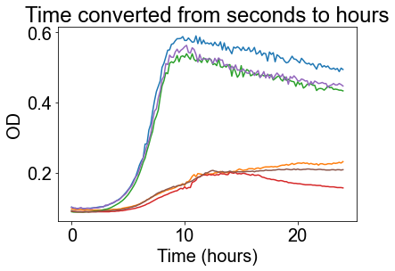

```python
fig,ax = plt.subplots()
ax.plot(plate.time,plate.data)
ax.set_title('Time converted from seconds to hours');
ax.set(**{'xlabel':'Time (hours)','ylabel':'OD'});
```

Growth curve analysis requires log tansformation which can not handle non-positive values. In some cases, OD (or other measurements) may be zero or negative. This avoids numerical issues by raising them to the minimum positive value in the curve.

```python
plate.raiseData()
```

**You can then log-transform your curves**

```python
plate.logData()
plate.data
```

| Sample_ID | 0 | 1 | 2 | 3 | 4 | 5 |
| --- | --- | --- | --- | --- | --- | --- |
| 0 | -2.292635 | -2.343407 | -2.430418 | -2.407946 | -2.292635 | -2.396896 |
| 1 | -2.312635 | -2.353878 | -2.441847 | -2.419119 | -2.322788 | -2.419119 |
| 2 | -2.333044 | -2.364460 | -2.441847 | -2.430418 | -2.312635 | -2.419119 |
| 3 | -2.333044 | -2.364460 | -2.441847 | -2.430418 | -2.343407 | -2.430418 |
| 4 | -2.322788 | -2.364460 | -2.441847 | -2.430418 | -2.322788 | -2.430418 |
| ... | ... | ... | ... | ... | ... | ... |
| 140 | -0.705220 | -1.487220 | -0.825536 | -1.845160 | -0.798508 | -1.575036 |
| 141 | -0.699165 | -1.482805 | -0.827822 | -1.851509 | -0.798508 | -1.570217 |
| 142 | -0.717440 | -1.474033 | -0.832409 | -1.851509 | -0.789658 | -1.570217 |
| 143 | -0.697155 | -1.482805 | -0.832409 | -1.851509 | -0.796288 | -1.575036 |
| 144 | -0.705220 | -1.465338 | -0.837018 | -1.857899 | -0.805197 | -1.570217 |

145 rows × 6 columns

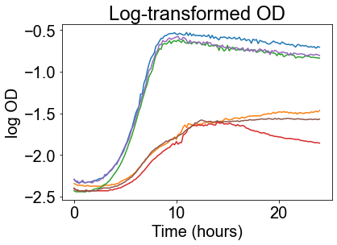

```python
fig,ax = plt.subplots()
ax.plot(plate.time,plate.data)
ax.set_title('Log-transformed OD');
ax.set(**{'xlabel':'Time (hours)','ylabel':'log OD'});
```

**Finally, you can adjust the initial OD so that it is centered at zero**

This can be done in two ways:

1. `poly=False`, for each curve, simply subtract OD at the first time point from subsequent time points
2. `poly=True`, for a group of curves, fit the first 5 time points to a polynomial of degree 3, estimate the initial OD basd on this fit, then subtract this value from OD at all time points for all curves.

Either way, recall that subtraction in the log-space is equivalent to division in the linear space.

$\log\left[OD(t)\right] - \log\left[OD(0)\right] = \log\left(\frac{OD(t)}{OD(0)}\right)$

This may not seem obvious but it affects the interpretation of your growth curves and growth parameters as I discuss elsewhere.

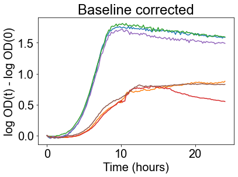

```python
plate.subtractBaseline(True,poly=True,groupby=['Substrate'])

fig,ax = plt.subplots()
ax.plot(plate.time,plate.data)
ax.set_title('Baseline corrected');
ax.set(**{'xlabel':'Time (hours)','ylabel':'log OD(t) - log OD(0)'});
```

## GrowthModel object

`GrowthModel` class allows you to model growth curve (individual or a group of replicates) as a Gaussian Process.

see `?GrowthModel` for more info.

```python
tmp = plate.time.join(plate.data)
tmp = tmp.melt(id_vars='Time',var_name='Sample_ID',value_name='OD')
tmp = tmp.drop(['Sample_ID'],axis=1) # T*R x 2 (where R is number of replicates)
tmp = tmp.dropna()
tmp
```

|  | Time | OD |
| --- | --- | --- |
| 0 | 0.000000 | -0.000442 |
| 1 | 0.166667 | -0.020443 |
| 2 | 0.333333 | -0.040852 |
| 3 | 0.500000 | -0.040852 |
| 4 | 0.666667 | -0.030595 |
| ... | ... | ... |
| 865 | 23.333333 | 0.822661 |
| 866 | 23.500000 | 0.827480 |
| 867 | 23.666667 | 0.827480 |
| 868 | 23.833333 | 0.822661 |
| 869 | 24.000000 | 0.827480 |

870 rows × 2 columns

Above, we combined time and OD into a single `pandas.DataFrame` then we melted the dataframe into a long form where columns include the measured (dependent variable) of `OD` and the explanatory (independent variable) of `Time`. You can also pass additional categorical covariates as well as additional columns with arbitrary name.

```python
tmp = plate.time.join(plate.data)
tmp = tmp.melt(id_vars='Time',var_name='Sample_ID',value_name='OD')

# let's include susbtrate label as an explantory variable
tmp.Sample_ID = tmp.Sample_ID.replace(plate.key.loc[:,'Substrate'].to_dict())

# variables must be numerical so I am converting substrate labels to numbers
tmp.Sample_ID = tmp.Sample_ID.replace({'Fructose':1,'Water':0})

# avoid any missing data
tmp = tmp.dropna()

# unnecessary, but to make it clear, I am updating column headers
tmp.columns = ['Time','Substrate','OD']
tmp
```

|  | Time | Substrate | OD |
| --- | --- | --- | --- |
| 0 | 0.000000 | 1 | -0.000442 |
| 1 | 0.166667 | 1 | -0.020443 |
| 2 | 0.333333 | 1 | -0.040852 |
| 3 | 0.500000 | 1 | -0.040852 |
| 4 | 0.666667 | 1 | -0.030595 |
| ... | ... | ... | ... |
| 865 | 23.333333 | 0 | 0.822661 |
| 866 | 23.500000 | 0 | 0.827480 |
| 867 | 23.666667 | 0 | 0.827480 |
| 868 | 23.833333 | 0 | 0.822661 |
| 869 | 24.000000 | 0 | 0.827480 |

870 rows × 3 columns

We will later return to the multi-dimensional input See Pooling example. For now, we will analyze the simple model where only time is is the independent varaiable. We will also analyze a single growth curve and later will attempt a model that pools replicate samples.

```python
tmp.iloc[0:145,:]
```

|  | Time | Substrate | OD |
| --- | --- | --- | --- |
| 0 | 0.000000 | 1 | -0.000442 |
| 1 | 0.166667 | 1 | -0.020443 |
| 2 | 0.333333 | 1 | -0.040852 |
| 3 | 0.500000 | 1 | -0.040852 |
| 4 | 0.666667 | 1 | -0.030595 |
| ... | ... | ... | ... |
| 140 | 23.333333 | 1 | 1.586973 |
| 141 | 23.500000 | 1 | 1.593027 |
| 142 | 23.666667 | 1 | 1.574752 |
| 143 | 23.833333 | 1 | 1.595037 |
| 144 | 24.000000 | 1 | 1.586973 |

145 rows × 3 columns

```python
gm = GrowthModel(df=tmp.iloc[0:145,:].drop('Substrate',axis=1),ARD=True)
gm
```

```
<libs.model.GrowthModel at 0x7fd7fecbd100>
```

**`df` attribute contains the input data**

```python
gm.df
```

|  | Time | OD |
| --- | --- | --- |
| 0 | 0.000000 | -0.000442 |
| 1 | 0.166667 | -0.020443 |
| 2 | 0.333333 | -0.040852 |
| 3 | 0.500000 | -0.040852 |
| 4 | 0.666667 | -0.030595 |
| ... | ... | ... |
| 140 | 23.333333 | 1.586973 |
| 141 | 23.500000 | 1.593027 |
| 142 | 23.666667 | 1.574752 |
| 143 | 23.833333 | 1.595037 |
| 144 | 24.000000 | 1.586973 |

145 rows × 2 columns

**`x` attribute is the model input for independent variables**

```python
gm.x
```

```
array([[ 0.        ],
       [ 0.16666667],
       [ 0.33333333],
       [ 0.5       ],
       [ 0.66666667],
       [ 0.83333333],
       [ 1.        ],
       [ 1.16666667],
       [ 1.33333333],
       [ 1.5       ],
       [ 1.66666667],
       [ 1.83333333],
       [ 2.        ],
       [ 2.16666667],
       [ 2.33333333],
       [ 2.5       ],
       [ 2.66666667],
       [ 2.83333333],
       [ 3.        ],
       [ 3.16666667],
       [ 3.33333333],
       [ 3.5       ],
       [ 3.66666667],
       [ 3.83333333],
       [ 4.        ],
       [ 4.16666667],
       [ 4.33333333],
       [ 4.5       ],
       [ 4.66666667],
       [ 4.83333333],
       [ 5.        ],
       [ 5.16666667],
       [ 5.33333333],
       [ 5.5       ],
       [ 5.66666667],
       [ 5.83333333],
       [ 6.        ],
       [ 6.16666667],
       [ 6.33333333],
       [ 6.5       ],
```

[output cut: 90 more lines]

```
       [21.66666667],
       [21.83333333],
       [22.        ],
       [22.16666667],
       [22.33333333],
       [22.5       ],
       [22.66666667],
       [22.83333333],
       [23.        ],
       [23.16666667],
       [23.33333333],
       [23.5       ],
       [23.66666667],
       [23.83333333],
       [24.        ]])
```

**`y` attribute is the model input for dependent variable**

```python
gm.y
```

```
array([[-4.42420686e-04],
       [-2.04430874e-02],
       [-4.08519590e-02],
       [-4.08519590e-02],
       [-3.05954589e-02],
       [-3.05954589e-02],
       [-4.08519590e-02],
       [-4.08519590e-02],
       [-3.05954589e-02],
       [-3.05954589e-02],
       [-3.05954589e-02],
       [-2.04430874e-02],
       [-2.04430874e-02],
       [-1.03927515e-02],
       [-4.42420686e-04],
       [ 9.40987576e-03],
       [ 9.40987576e-03],
       [ 1.91660507e-02],
       [ 3.83974126e-02],
       [ 4.78761566e-02],
       [ 7.57849447e-02],
       [ 9.39672638e-02],
       [ 1.11824881e-01],
       [ 1.38027254e-01],
       [ 1.71928805e-01],
       [ 1.96621418e-01],
       [ 2.28624149e-01],
       [ 2.67238985e-01],
       [ 3.11690748e-01],
       [ 3.54250362e-01],
       [ 4.01716899e-01],
       [ 4.47032095e-01],
       [ 5.08401042e-01],
       [ 5.71822868e-01],
       [ 6.20879025e-01],
       [ 7.02557056e-01],
       [ 7.82599764e-01],
       [ 8.35475516e-01],
       [ 8.73374789e-01],
       [ 1.02279173e+00],
```

[output cut: 90 more lines]

```
       [ 1.58899483e+00],
       [ 1.61688508e+00],
       [ 1.61884779e+00],
       [ 1.60104316e+00],
       [ 1.60899549e+00],
       [ 1.60104316e+00],
       [ 1.60701333e+00],
       [ 1.59302709e+00],
       [ 1.58899483e+00],
       [ 1.59503714e+00],
       [ 1.58697258e+00],
       [ 1.59302709e+00],
       [ 1.57475247e+00],
       [ 1.59503714e+00],
       [ 1.58697258e+00]])
```

If `GrowthModel` recognizes that there are additional variables beyond time, it also computes the measurement variance across all replicate samples. Here, it would compute the measurement variances for growth on fructose and measurement variance for grwoth on water. The errors are organized in long-form like the `tmp` dataframe.

```python
gm.error
```

```
array([[0.],
       [0.],
       [0.],
       [0.],
       [0.],
       [0.],
       [0.],
       [0.],
       [0.],
       [0.],
       [0.],
       [0.],
       [0.],
       [0.],
       [0.],
       [0.],
       [0.],
       [0.],
       [0.],
       [0.],
       [0.],
       [0.],
       [0.],
       [0.],
       [0.],
       [0.],
       [0.],
       [0.],
       [0.],
       [0.],
       [0.],
       [0.],
       [0.],
       [0.],
       [0.],
       [0.],
       [0.],
       [0.],
       [0.],
       [0.],
```

[output cut: 90 more lines]

```
       [0.],
       [0.],
       [0.],
       [0.],
       [0.],
       [0.],
       [0.],
       [0.],
       [0.],
       [0.],
       [0.],
       [0.],
       [0.],
       [0.],
       [0.]])
```

**You can now fit the model using `GPy` in the backend**

```python
gm.fit()
gm.model
```

**Model**: GP regression  
**Objective**: -360.8961273489176  
**Number of Parameters**: 3  
**Number of Optimization Parameters**: 3  
**Updates**: True

| **GP_regression.** | **value** | **constraints** | **priors** |
| --- | --- | --- | --- |
| rbf.variance | 0.8446783061070134 | +ve |  |
| rbf.lengthscale | 2.792099660898179 | +ve |  |
| Gaussian_noise.variance | 0.00016762324874182143 | +ve |  |

## Cruve object

The `GrowthModel().run()` method not only fits the `GrowthModel`, but predicts the growth curve, its first-order derivative, and its second-order derivative.

```python
curve = gm.run()
curve
```

```
<libs.curve.GrowthCurve at 0x7fd7fed8eee0>
```

Because we are jointly modelling multiple curves with differnt starting initial values (baseline), `GrowthModel` will assume that that baseline is zero.

$\log\left[OD(t)\right] - \log\left[OD(0)\right] = 0$

so the growth parameter estimates for AUC, carrying capacity, and death will be relative to th starting OD. See below for more details.

```python
curve.baseline
```

```
1.0
```

The `data` method summarizes different formulations of the input and predicted data.

1. Time
2. GP_Input: Actual input to the GP model.
3. GP_Output: Prediction by the GP model for mean grwoth.
4. GP_Derivative: Pediction by the GP model for derivative of growth.
5. OD_Growth_Data: GP_Input but converted to linear scale.
6. OD_Growth_Fit: GP_Output but converted to linear scale.
7. OD_Fit: OD_Growth_Fit

```python
curve.data()
```

|  | Time | GP_Input | GP_Output | GP_Derivative | OD_Growth_Data | OD_Growth_Fit | OD_Fit |
| --- | --- | --- | --- | --- | --- | --- | --- |
| 0 | 0.000000 | -0.000442 | -0.014018 | -0.039502 | 0.000000 | 0.000000 | 0.986080 |
| 1 | 0.166667 | -0.020443 | -0.020189 | -0.034521 | -0.019793 | -0.006067 | 0.980013 |
| 2 | 0.333333 | -0.040852 | -0.025511 | -0.029305 | -0.039586 | -0.011269 | 0.974811 |
| 3 | 0.500000 | -0.040852 | -0.029942 | -0.023812 | -0.039586 | -0.015578 | 0.970502 |
| 4 | 0.666667 | -0.030595 | -0.033431 | -0.018004 | -0.029690 | -0.018959 | 0.967121 |
| ... | ... | ... | ... | ... | ... | ... | ... |
| 140 | 23.333333 | 1.586973 | 1.592528 | -0.009288 | 3.889368 | 3.930081 | 4.916161 |
| 141 | 23.500000 | 1.593027 | 1.590837 | -0.011144 | 3.919058 | 3.921775 | 4.907855 |
| 142 | 23.666667 | 1.574752 | 1.588765 | -0.013880 | 3.829988 | 3.911614 | 4.897694 |
| 143 | 23.833333 | 1.595037 | 1.586157 | -0.017576 | 3.928954 | 3.898860 | 4.884940 |
| 144 | 24.000000 | 1.586973 | 1.582849 | -0.022300 | 3.889368 | 3.882726 | 4.868806 |

145 rows × 7 columns

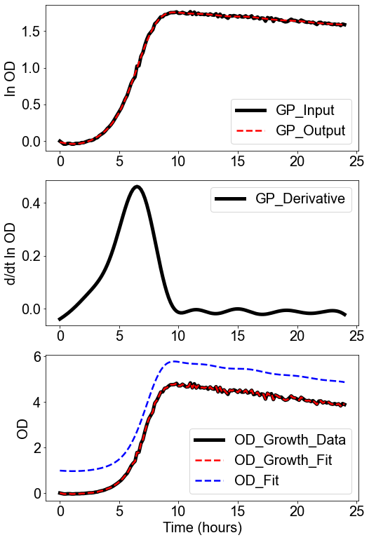

```python
tmpc = curve.data()


fig,axes = plt.subplots(3,1,figsize=[8,13])
axes = np.ravel(axes)

ax = axes[0]
ax.plot(tmpc.Time,tmpc.GP_Input,label='GP_Input',color='black',lw=5)
ax.plot(tmpc.Time,tmpc.GP_Output,label='GP_Output',color='red',lw=2.5,ls='--')
ax.set_ylabel('ln OD')
ax.legend()

#fig,ax = plt.subplots(figsize=[8,4])
ax = axes[1]
ax.plot(tmpc.Time,tmpc.GP_Derivative,label='GP_Derivative',color='black',lw=5)
ax.set_ylabel('d/dt ln OD')
ax.legend()

#fig,ax = plt.subplots(figsize=[8,4])
ax = axes[2]
ax.plot(tmpc.Time,tmpc.OD_Growth_Data,label='OD_Growth_Data',color='black',lw=5)
ax.plot(tmpc.Time,tmpc.OD_Growth_Data,label='OD_Growth_Fit',color='red',lw=2.5,ls='--')
ax.plot(tmpc.Time,tmpc.OD_Fit,label='OD_Fit',color='blue',lw=2.5,ls='--')
ax.legend()
ax.set_xlabel('Time (hours)')
ax.set_ylabel('OD')
```

**Grwoth parameters are stored in a dictionary**

`diauxie` is a binary variable that indicates if diauxic shift was detected (1) or not (0).

`df_dx` is a `pandas.DataFrame` that contains one row for each unique growth phase with columns being the growth parameters. If there is no diauxie, the dataframe has a single row.

```python
curve.params
```

```
{'auc_lin': 76.27266003059205,
 'auc_log': 30.23957749859053,
 'k_lin': 4.794029686752292,
 'k_log': 1.754422704363531,
 't_k': 9.666666666666666,
 'gr': 0.46112918038997325,
 'dr': -0.022300089604496882,
 'td': 1.5031518499301135,
 't_gr': 6.5,
 't_dr': 24.0,
 'death_lin': 0.9113038876376032,
 'death_log': 0.17157395980796863,
 'lagC': 4.33886417420166,
 'lagP': 1.5,
 't0': 0.0,
 'tf': 24.0,
 'diauxie': 0,
 'df_dx':    dx_auc_lin  dx_auc_log  dx_k_lin  dx_k_log    dx_t_k     dx_gr   dx_dr  \
 0    76.27266   30.239577   4.79403  1.754423  9.666667  0.461129 -0.0223

       dx_td  dx_t_gr  dx_t_dr  dx_death_lin  dx_death_log   dx_lagC  dx_lagP  \
 0  1.503152      6.5     24.0      0.911304      0.171574  4.338864      1.5

    dx_t0  dx_tf
 0    0.0   24.0  }
```

```python
curve.params['df_dx']
```

|  | dx_auc_lin | dx_auc_log | dx_k_lin | dx_k_log | dx_t_k | dx_gr | dx_dr | dx_td | dx_t_gr | dx_t_dr | dx_death_lin | dx_death_log | dx_lagC | dx_lagP | dx_t0 | dx_tf |
| --- | --- | --- | --- | --- | --- | --- | --- | --- | --- | --- | --- | --- | --- | --- | --- | --- |
| 0 | 76.27266 | 30.239577 | 4.79403 | 1.754423 | 9.666667 | 0.461129 | -0.0223 | 1.503152 | 6.5 | 24.0 | 0.911304 | 0.171574 | 4.338864 | 1.5 | 0.0 | 24.0 |

## Pooling example

We are using the tmp variable from earlier

```python
tmp
```

|  | Time | Substrate | OD |
| --- | --- | --- | --- |
| 0 | 0.000000 | 1 | -0.000442 |
| 1 | 0.166667 | 1 | -0.020443 |
| 2 | 0.333333 | 1 | -0.040852 |
| 3 | 0.500000 | 1 | -0.040852 |
| 4 | 0.666667 | 1 | -0.030595 |
| ... | ... | ... | ... |
| 865 | 23.333333 | 0 | 0.822661 |
| 866 | 23.500000 | 0 | 0.827480 |
| 867 | 23.666667 | 0 | 0.827480 |
| 868 | 23.833333 | 0 | 0.822661 |
| 869 | 24.000000 | 0 | 0.827480 |

870 rows × 3 columns

```python
conditions = tmp.drop(['Time','OD'],axis=1).drop_duplicates().reset_index(drop=True)
conditions
```

|  | Substrate |
| --- | --- |
| 0 | 1 |
| 1 | 0 |

```python
gms = {}
curves = {}

for idx,row in conditions.iterrows():
    print(row.to_dict())
    df_cond = subsetDf(tmp,row.to_dict())
    df_cond = df_cond.drop(labels=row.keys(),axis=1)
    gms[idx] = GrowthModel(df=df_cond,ARD=True)
    curves[idx] = gms[idx].run()
    print(gms[idx].model)
    print()
```

```
{'Substrate': 1}

Name : GP regression
Objective : -672.7603429906137
Number of Parameters : 3
Number of Optimization Parameters : 3
Updates : True
Parameters:
  GP_regression.           |                  value  |  constraints  |  priors
  rbf.variance             |     0.8872139291158524  |      +ve      |
  rbf.lengthscale          |     3.2030737519782266  |      +ve      |
  Gaussian_noise.variance  |  0.0021326326464497967  |      +ve      |

{'Substrate': 0}

Name : GP regression
Objective : -567.6865741276025
Number of Parameters : 3
Number of Optimization Parameters : 3
Updates : True
Parameters:
  GP_regression.           |                 value  |  constraints  |  priors
  rbf.variance             |   0.21469910943594195  |      +ve      |
  rbf.lengthscale          |     6.450779141771983  |      +ve      |
  Gaussian_noise.variance  |  0.003895365122942465  |      +ve      |
```

```python
curves[0].data()
```

|  | Time | GP_Input | GP_Output | GP_Derivative | OD_Growth_Data | OD_Growth_Fit | OD_Fit |
| --- | --- | --- | --- | --- | --- | --- | --- |
| 0 | 0.000000 | -0.000442 | -0.005236 | -0.051763 | 0.000000 | 0.000000 | 0.994777 |
| 1 | 0.166667 | -0.020443 | -0.013150 | -0.043123 | -0.019793 | -0.007841 | 0.986936 |
| 2 | 0.333333 | -0.040852 | -0.019590 | -0.034117 | -0.039586 | -0.014177 | 0.980600 |
| 3 | 0.500000 | -0.040852 | -0.024513 | -0.024943 | -0.039586 | -0.018992 | 0.975785 |
| 4 | 0.666667 | -0.030595 | -0.027906 | -0.015785 | -0.029690 | -0.022297 | 0.972480 |
| ... | ... | ... | ... | ... | ... | ... | ... |
| 430 | NaN | 1.496606 | NaN | NaN | 3.466948 | NaN | NaN |
| 431 | NaN | 1.496606 | NaN | NaN | 3.466948 | NaN | NaN |
| 432 | NaN | 1.505456 | NaN | NaN | 3.506650 | NaN | NaN |
| 433 | NaN | 1.498826 | NaN | NaN | 3.476873 | NaN | NaN |
| 434 | NaN | 1.489917 | NaN | NaN | 3.437171 | NaN | NaN |

435 rows × 7 columns

Similar to the uni-dimentional data, the `data` method summarizes different formulations of the input and predicted data.

1. Time
2. GP_Input: Actual input to the GP model.
3. GP_Output: Prediction by the GP model for mean grwoth.
4. GP_Derivative: Pediction by the GP model for derivative of growth.
5. OD_Growth_Data: GP_Input but converted to linear scale.
6. OD_Growth_Fit: GP_Output but converted to linear scale.
7. OD_Fit: OD_Growth_Fit

**HOWEVER**, here `GP_Input` and `OD_Growth_Data` are `n`-times lager than the other variables, where `n` is the number of pooled samples or pooled replicates.

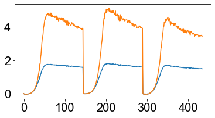

```python
fig,ax = plt.subplots(figsize=[6,3])

ax.plot(curves[0].data().GP_Input)
ax.plot(curves[0].data().OD_Growth_Data)
```

Here it is plotted differently.

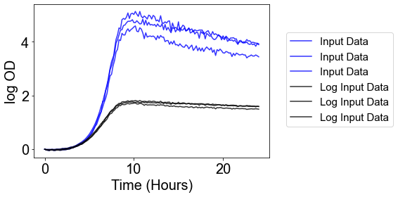

```python
n_samples = int(curves[0].data().shape[0] / curves[0].data().dropna().shape[0])
time = list(curves[0].data().Time.dropna()) #* n_samples

# create dummy Sample ID variable to simplify plotting
sample_id = np.ravel([[ii]*len(time) for ii in range(n_samples)])

# repeat time for number of samples
time = time * n_samples

# put together into a pandas.DataFrame to simplify plotting.
tmpc = pd.DataFrame([sample_id,time,curves[0].data().GP_Input,curves[0].data().OD_Growth_Data],
                    index=['Sample_ID','Time','GP_Input','OD_Growth_Data']).T

fig,ax = plt.subplots(figsize=[6,4])

tmp_gp_input = tmpc.pivot(index='Time',columns='Sample_ID',values='GP_Input')
tmp_od_grwoth_data = tmpc.pivot(index='Time',columns='Sample_ID',values='OD_Growth_Data')


ax.plot(tmp_od_grwoth_data.index.values,tmp_od_grwoth_data.values,
        color=(0,0,1,0.8),label='Input Data');
ax.plot(tmp_gp_input.index.values, tmp_gp_input.values,
        color=(0,0,0,0.8),label='Log Input Data');

ax.set_xlabel('Time (Hours)',fontsize=20)
ax.set_ylabel('log OD',fontsize=20)
largeTickLabels(ax,fontsize=20)
ax.legend(bbox_to_anchor=(1.05,.85),fontsize=15)
```

However we are interested in simply the model estimates which we can store into a single pandas.DataFrame as shown below

```python
data_ls = []

for idx,condition in conditions.iterrows():

    time = pd.DataFrame(gms[idx].x_new,columns=['Time'])

    # mean and covariance of the latent function
    mu0, var0 = np.ravel(gms[idx].y0), np.ravel(np.diag(gms[idx].cov0))

    # mean and covariance of the derivative latent function
    mu1, var1 = np.ravel(gms[idx].y1), np.ravel(np.diag(gms[idx].cov1))

    # Gaussian noise hyperparameter, i.e. time-independent noise term
    sigma_noise = np.ravel([gms[idx].noise]*time.shape[0])

    mu_var = pd.DataFrame([mu0,var0,mu1,var1,sigma_noise],
                         index=['mu','Sigma','mu1','Sigma1','Noise']).T

    gp_data = pd.DataFrame([list(condition.values)]*len(mu0),columns=condition.keys())
    gp_data = gp_data.join(time).join(mu_var)
    data_ls.append(gp_data)

gp_data = pd.concat(data_ls,sort=False).reset_index(drop=True)
gp_data
```

|  | Substrate | Time | mu | Sigma | mu1 | Sigma1 | Noise |
| --- | --- | --- | --- | --- | --- | --- | --- |
| 0 | 1 | 0.000000 | -0.005236 | 0.000311 | -0.051763 | 0.001507 | 0.002133 |
| 1 | 1 | 0.166667 | -0.013150 | 0.000180 | -0.043123 | 0.000986 | 0.002133 |
| 2 | 1 | 0.333333 | -0.019590 | 0.000117 | -0.034117 | 0.000624 | 0.002133 |
| 3 | 1 | 0.500000 | -0.024513 | 0.000091 | -0.024943 | 0.000384 | 0.002133 |
| 4 | 1 | 0.666667 | -0.027906 | 0.000083 | -0.015785 | 0.000235 | 0.002133 |
| ... | ... | ... | ... | ... | ... | ... | ... |
| 285 | 0 | 23.333333 | 0.747025 | 0.000114 | -0.013299 | 0.000111 | 0.003895 |
| 286 | 0 | 23.500000 | 0.744732 | 0.000139 | -0.014223 | 0.000133 | 0.003895 |
| 287 | 0 | 23.666667 | 0.742283 | 0.000172 | -0.015165 | 0.000158 | 0.003895 |
| 288 | 0 | 23.833333 | 0.739676 | 0.000217 | -0.016125 | 0.000187 | 0.003895 |
| 289 | 0 | 24.000000 | 0.736907 | 0.000274 | -0.017100 | 0.000220 | 0.003895 |

290 rows × 7 columns

Above, we have a dataframe that has meta-data columns indicating the unique conditions, and columns that indicate model predictions:

**This is how you can plot the prediction of the latent function**

```python
def mean_and_bands(ax,df,add_noise=True,derivative=False,confidence=95):

    alpha = (100 - confidence)/100
    z_value = (1 - alpha/2)

    from scipy.stats import norm
    scaler = norm.ppf(z_value) # 95% confidence intervals

    if not derivative:
        mu = df.mu
        cov = df.Sigma
    else:
        mu = df.mu1
        cov = df.Sigma1

    if add_noise:
        Sigma = cov + df.Noise
    else:
        Sigma = cov

    x_time = df.Time
    y_avg = mu
    y_low = mu - scaler*np.sqrt(Sigma)
    y_upp = mu + scaler*np.sqrt(Sigma)

    return (x_time,y_avg,y_low,y_upp)
```

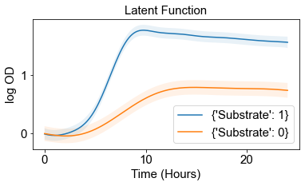

```python
fig,ax = plt.subplots(figsize=[6,3])

for idx, row in conditions.iterrows():

    tmp_gp = subsetDf(gp_data,row.to_dict())

    x_time,y_avg,y_low,y_upp = mean_and_bands(ax,tmp_gp,add_noise=True)

    ax.plot(x_time,y_avg,label=row.to_dict())
    ax.fill_between(x=x_time,y1=y_low,y2=y_upp,alpha=0.1)

ax.legend(bbox_to_anchor=(1.05,0.65))

ax.set_xlabel('Time (Hours)',fontsize=15)
ax.set_ylabel('log OD',fontsize=15)
largeTickLabels(ax,fontsize=15)
ax.legend(loc=4,fontsize=15)
ax.set_title('Latent Function',fontsize=15);
```

This is how you can plot the prediction of the *derivative* of the latent function

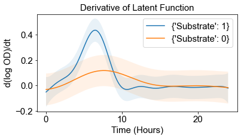

```python
fig,ax = plt.subplots(figsize=[6,3])

for idx, row in conditions.iterrows():

    tmp_gp = subsetDf(gp_data,row.to_dict())

    x_time,y_avg,y_low,y_upp = mean_and_bands(ax,tmp_gp,add_noise=True,derivative=True)

    ax.plot(x_time,y_avg,label=row.to_dict())
    ax.fill_between(x=x_time,y1=y_low,y2=y_upp,alpha=0.1)

ax.legend(bbox_to_anchor=(1.05,0.65))

ax.set_xlabel('Time (Hours)',fontsize=15)
ax.set_ylabel('d(log OD)/dt',fontsize=15)
largeTickLabels(ax,fontsize=15)
ax.legend(loc=1,fontsize=15)
ax.set_title('Derivative of Latent Function',fontsize=15);
```

**Here are the parameters**: you can extract only the means or the means and standard deviations.

```python
curves[0].params
```

```
{'auc_lin': 74.08227944357785,
 'auc_log': 29.9000213026098,
 'k_lin': 4.826653566677286,
 'k_log': 1.7615460660033073,
 't_k': 9.833333333333334,
 'gr': 0.4351388239735125,
 'dr': -0.031763527580060735,
 'td': 1.5929334326696118,
 't_gr': 6.5,
 't_dr': 10.666666666666666,
 'death_lin': 1.0837211996563036,
 'death_log': 0.20599226291130046,
 'lagC': 4.2228335721544195,
 'lagP': 1.3333333333333333,
 't0': 0.0,
 'tf': 24.0,
 'diauxie': 0,
 'df_dx':    dx_auc_lin  dx_auc_log  dx_k_lin  dx_k_log    dx_t_k     dx_gr     dx_dr  \
 0   74.082279   29.900021  4.826654  1.761546  9.833333  0.435139 -0.031764

       dx_td  dx_t_gr    dx_t_dr  dx_death_lin  dx_death_log   dx_lagC  \
 0  1.592933      6.5  10.666667      1.083721      0.205992  4.222834

     dx_lagP  dx_t0  dx_tf
 0  1.333333    0.0   24.0  }
```

```python
curves[0].sample().posterior
```

```
{'mean(auc_lin)': 74.10920229508673,
 'mean(auc_log)': 29.909787281052278,
 'mean(k_lin)': 4.826549276315117,
 'mean(k_log)': 1.7616705912045432,
 'mean(t_k)': 9.77,
 'mean(gr)': 0.43516704639222903,
 'mean(dr)': -0.04250706437113829,
 'mean(td)': 1.5933109835105137,
 'mean(t_gr)': 6.468333333333334,
 'mean(t_dr)': 16.451666666666668,
 'mean(death_lin)': 1.0807124949457554,
 'mean(death_log)': 0.20545658824209517,
 'mean(lagC)': 4.218940790579507,
 'mean(lagP)': 1.3816666666666666,
 'std(auc_lin)': 0.47017564084833186,
 'std(auc_log)': 0.05223884098437252,
 'std(k_lin)': 0.04345900582303403,
 'std(k_log)': 0.006464686892533931,
 'std(t_k)': 0.12027839013537672,
 'std(gr)': 0.007583535801856875,
 'std(dr)': 0.019480464747271952,
 'std(td)': 0.02787967442728814,
 'std(t_gr)': 0.07375985543538997,
 'std(t_dr)': 5.855024365916592,
 'std(death_lin)': 0.0848040693320632,
 'std(death_log)': 0.01757131804219809,
 'std(lagC)': 0.04009110330066765,
 'std(lagP)': 0.2275805995530579}
```

```python
curves[1].sample().posterior
```

```
{'mean(auc_lin)': 17.939726555262727,
 'mean(auc_log)': 12.282595533668786,
 'mean(k_lin)': 1.1984968020718156,
 'mean(k_log)': 0.7886102060637665,
 'mean(t_k)': 15.148333333333333,
 'mean(gr)': 0.11726505720599784,
 'mean(dr)': -0.017902999132222958,
 'mean(td)': 5.915721239766617,
 'mean(t_gr)': 7.621666666666667,
 'mean(t_dr)': 22.91833333333333,
 'mean(death_lin)': 0.11128637148719928,
 'mean(death_log)': 0.05200550227790204,
 'mean(lagC)': 4.639883952243414,
 'mean(lagP)': 2.466666666666667,
 'std(auc_lin)': 0.4530562966680967,
 'std(auc_log)': 0.07339149503021895,
 'std(k_lin)': 0.02147779307782217,
 'std(k_log)': 0.005843482820310608,
 'std(t_k)': 1.3706673397396452,
 'std(gr)': 0.003343309427975638,
 'std(dr)': 0.010388819559635084,
 'std(td)': 0.16937329540452845,
 'std(t_gr)': 0.1738437834810161,
 'std(t_dr)': 2.2391395202724174,
 'std(death_lin)': 0.03263552233775529,
 'std(death_log)': 0.01557920368807274,
 'std(lagC)': 0.1106022696053838,
 'std(lagP)': 0.1895117478716537}
```

```python
def getConfInts(mean,std,conf=0.95):

    from scipy.stats import norm
    alpha = 1-conf
    z_value = (1-alpha/2)
    scaler = norm.ppf(z_value)

    low, upp = mean-scaler*std, mean+scaler*std
    return low,upp

tmpc = curves[0].sample().posterior

getConfInts(tmpc['mean(auc_lin)'],tmpc['std(auc_lin)'],conf=0.975)
```

```
(73.06644897171864, 75.1391559675049)
```

```python
params = [ii.split('(')[1][:-1] for ii in tmpc.keys() if 'mean' in ii ]

for param in params:

    mu = tmpc['mean({})'.format(param)]
    std = tmpc['std({})'.format(param)]

    low,high = getConfInts(mu,std,conf=0.975)

    print('{}:\t{:.2f}\t({:.2f},{:.2f})'.format(param,mu,low,high))
```

```
auc_lin:	74.10	(73.07,75.14)
auc_log:	29.90	(29.79,30.01)
k_lin:	4.82	(4.72,4.93)
k_log:	1.76	(1.74,1.78)
t_k:	9.78	(9.55,10.00)
gr:	0.43	(0.42,0.45)
dr:	-0.04	(-0.08,-0.00)
td:	1.59	(1.54,1.64)
t_gr:	6.47	(6.33,6.62)
t_dr:	16.11	(1.93,30.30)
death_lin:	1.09	(0.91,1.27)
death_log:	0.21	(0.17,0.24)
lagC:	4.22	(4.14,4.30)
lagP:	1.32	(0.70,1.94)
```